# Introduction to Regression - Life Expectancy Data

```r
library(tidyverse)
library(naniar)
library(GGally)
```

# Data Description

The Global Health Observatory (GHO) data repository under World Health Organization (WHO) keeps track of the health status as well as many other related factors for all countries The datasets are made available to public for the purpose of health data analysis. The dataset related to life expectancy, health factors for 193 countries has been collected from the same WHO data repository website and its corresponding economic data was collected from United Nation website. Among all categories of health-related factors only those critical factors were chosen which are more representative. It has been observed that in the past 15 years , there has been a huge development in health sector resulting in improvement of human mortality rates especially in the developing nations in comparison to the past 30 years. Therefore, in this project we have considered data from year 2000-2015 for 193 countries for further analysis. The individual data files have been merged together into a single dataset. On initial visual inspection of the data showed some missing values. As the datasets were from WHO, we found no evident errors. Missing data was handled in R software by using Missmap command. The result indicated that most of the missing data was for population, Hepatitis B and GDP. The missing data were from less known countries like Vanuatu, Tonga, Togo,Cabo Verde etc. Finding all data for these countries was difficult and hence, it was decided that we exclude these countries from the final model dataset. The final merged file(final dataset) consists of 22 Columns and 2938 rows which meant 20 predicting variables. All predicting variables was then divided into several broad categories:Immunization related factors, Mortality factors, Economical factors and Social factors.

## Variables

Life expectancy: Life Expectancy in age

Adult Mortality: Adult Mortality Rates of both sexes (probability of dying between 15 and 60 years per 1000 population)

Infant deaths: Number of Infant Deaths per 1000 population

Alcohol: Alcohol, recorded per capita (15+) consumption (in litres of pure alcohol)

Percentage expenditure: Expenditure on health as a percentage of Gross Domestic Product per capita(%)

Hepatitis B: Hepatitis B (HepB) immunization coverage among 1-year-olds (%)

Measles: Measles - number of reported cases per 1000 population

BMI: Average Body Mass Index of entire population

under-five deaths: Number of under-five deaths per 1000 population

Polio: Polio (Pol3) immunization coverage among 1-year-olds (%)

Total expenditure: General government expenditure on health as a percentage of total government expenditure (%)

Diphtheria: Diphtheria tetanus toxoid and pertussis (DTP3) immunization coverage among 1-year-olds (%)

HIV/AIDS: Deaths per 1 000 live births HIV/AIDS (0-4 years)

GDP: Gross Domestic Product per capita (in USD)

Population: Population of the country

thinness 1-19 years: Prevalence of thinness among children and adolescents for Age 10 to 19 (%)

thinness 5-9 years: Prevalence of thinness among children for Age 5 to 9(%)

Income composition of resources: Human Development Index in terms of income composition of resources (index ranging from 0 to 1)

Schooling: Number of years of Schooling(years)

## Data Preprocessing

To maintain the dependency of observations, one-year (2014) dataset was selected. Rows with missing observations were removed.

```r
life_expectancy <- read.csv("life_expectancy_kaggle.csv")
life_expectancy_14 = life_expectancy %>%
        filter(year == "2014") %>%
        select(-year)
LE=na.omit(life_expectancy_14)
```

# Data Understanding

Let’s see the first few observations in the dataset and the structure of the variables.

```r
head(LE)
```

```
##        country     status life_exp adult_mort inf_death alcohol    perc_exp
## 1    Australia  Developed     82.7          6         1    9.71 10769.36305
## 5      Ireland  Developed     81.2         66         0   10.75   746.36705
## 6  Netherlands  Developed     81.7         58         1    0.01  1491.70360
## 9        Spain  Developed     82.6         58         1    0.01    42.98848
## 10   Argentina Developing     76.2        118         8    7.93   847.37175
## 11      Greece Developing     88.0         73         0    7.53  2163.04341
##    hep_B measles  BMI under_5_d polio tot_exp diphtheria HIV        GDP
## 1     91     340 66.1         1    92    9.42         92 0.1 62214.6912
## 5     95      33 62.1         0    96    7.78         96 0.1  5553.3262
## 6     92     140 61.6         1    96    1.90         96 0.1 52157.4687
## 9     96     154 66.0         1    97    9.30         97 0.1   296.4722
## 10    94       1 62.2         9    92    4.79         94 0.1 12245.2565
## 11    96       1 66.0         0    99    8.80         99 0.1 21673.7817
##         pop thin10_19 thin5_9 Income school
## 1   2346694       0.6     0.6  0.936   20.4
## 5   4617225       0.3     0.2  0.910   18.6
## 6    168658       1.0     0.9  0.923   18.1
## 9   4648882       0.6     0.5  0.877   17.6
## 10 42981515       1.0     0.9  0.825   17.3
## 11  1892413       0.8     0.7  0.862   17.2
```

```r
str(LE)
```

```
## 'data.frame':    131 obs. of  21 variables:
##  $ country   : chr  "Australia" "Ireland" "Netherlands" "Spain" ...
##  $ status    : chr  "Developed" "Developed" "Developed" "Developed" ...
##  $ life_exp  : num  82.7 81.2 81.7 82.6 76.2 88 89 89 77.3 73.4 ...
##  $ adult_mort: int  6 66 58 58 118 73 69 78 122 169 ...
##  $ inf_death : int  1 0 1 1 8 0 2 0 0 0 ...
##  $ alcohol   : num  9.71 10.75 0.01 0.01 7.93 ...
##  $ perc_exp  : num  10769 746 1492 43 847 ...
##  $ hep_B     : int  91 95 92 96 94 96 88 98 93 94 ...
##  $ measles   : int  340 33 140 154 1 1 443 0 0 11 ...
##  $ BMI       : num  66.1 62.1 61.6 66 62.2 66 61.9 6.9 59.4 61.9 ...
##  $ under_5_d : int  1 0 1 1 9 0 3 0 0 0 ...
##  $ polio     : int  92 96 96 97 92 99 94 98 93 93 ...
##  $ tot_exp   : num  9.42 7.78 1.9 9.3 4.79 8.8 11.3 9.5 6.38 6.55 ...
##  $ diphtheria: int  92 96 96 97 94 99 95 98 93 93 ...
##  $ HIV       : num  0.1 0.1 0.1 0.1 0.1 0.1 0.1 0.1 0.1 0.1 ...
##  $ GDP       : num  62215 5553 52157 296 12245 ...
##  $ pop       : num  2346694 4617225 168658 4648882 42981515 ...
##  $ thin10_19 : num  0.6 0.3 1 0.6 1 0.8 1.1 0.7 1.9 2.6 ...
##  $ thin5_9   : num  0.6 0.2 0.9 0.5 0.9 0.7 1.1 0.5 1.9 2.7 ...
##  $ Income    : num  0.936 0.91 0.923 0.877 0.825 0.862 0.92 0.837 0.86 0.841 ...
##  $ school    : num  20.4 18.6 18.1 17.6 17.3 17.2 17 16.8 16.5 16.5 ...
##  - attr(*, "na.action")= 'omit' Named int [1:52] 2 3 4 7 8 12 26 27 28 29 ...
##   ..- attr(*, "names")= chr [1:52] "2" "3" "4" "7" ...
```

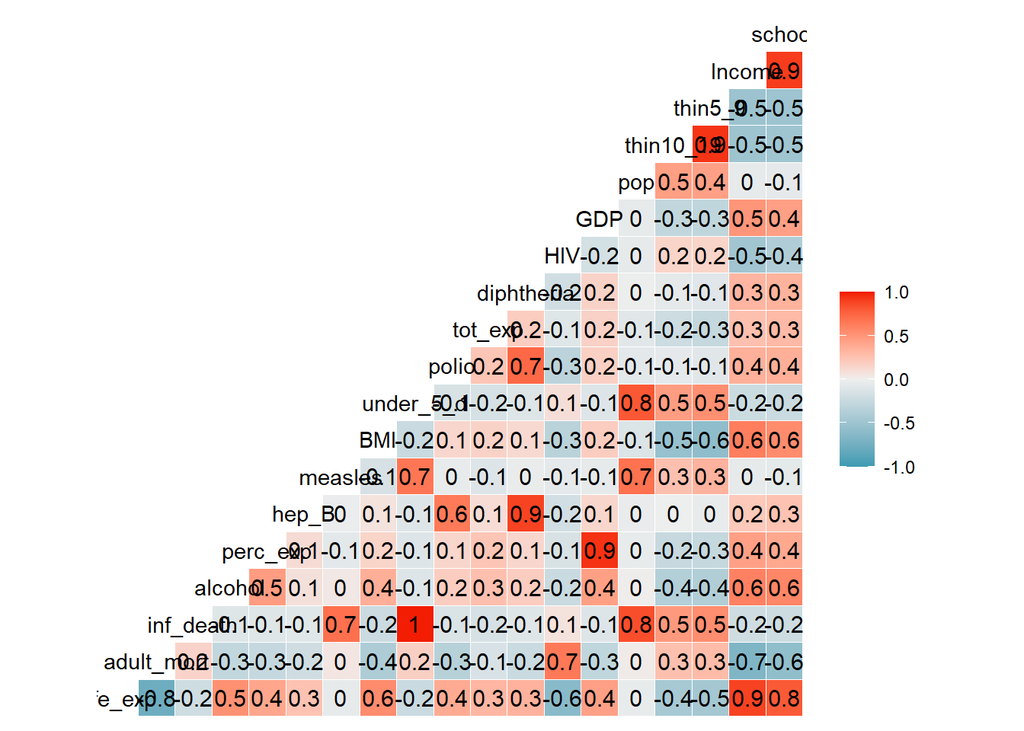

```r
ggcorr(LE[,-c(1,2)], label = TRUE)
```

Let’s have a closer look at the variables which shows relatively high correlation with life expectancy.

```r
summary(LE)
```

```
##    country             status             life_exp       adult_mort
##  Length:131         Length:131         Min.   :48.10   Min.   :  2.0
##  Class :character   Class :character   1st Qu.:64.65   1st Qu.: 74.5
##  Mode  :character   Mode  :character   Median :72.00   Median :144.0
##                                        Mean   :70.52   Mean   :160.4
##                                        3rd Qu.:75.80   3rd Qu.:225.0
##                                        Max.   :89.00   Max.   :522.0
##    inf_death         alcohol          perc_exp             hep_B
##  Min.   :  0.00   Min.   : 0.010   Min.   :    0.443   Min.   : 2.00
##  1st Qu.:  0.00   1st Qu.: 0.010   1st Qu.:   48.311   1st Qu.:78.00
##  Median :  3.00   Median : 0.010   Median :  198.734   Median :91.00
##  Mean   : 28.56   Mean   : 3.061   Mean   :  850.874   Mean   :81.71
##  3rd Qu.: 20.00   3rd Qu.: 6.305   3rd Qu.:  718.324   3rd Qu.:96.00
##  Max.   :957.00   Max.   :15.190   Max.   :16255.162   Max.   :99.00
##     measles             BMI          under_5_d           polio
##  Min.   :    0.0   Min.   : 2.00   Min.   :   0.00   Min.   : 8.0
##  1st Qu.:    0.0   1st Qu.:22.85   1st Qu.:   1.00   1st Qu.:78.0
##  Median :   10.0   Median :45.90   Median :   3.00   Median :92.0
##  Mean   : 2042.9   Mean   :40.48   Mean   :  38.24   Mean   :83.5
##  3rd Qu.:  289.5   3rd Qu.:59.45   3rd Qu.:  25.50   3rd Qu.:97.0
##  Max.   :79563.0   Max.   :77.10   Max.   :1200.00   Max.   :99.0
##     tot_exp         diphtheria         HIV              GDP
##  Min.   : 1.210   Min.   : 2.00   Min.   :0.1000   Min.   :    12.28
##  1st Qu.: 4.485   1st Qu.:80.00   1st Qu.:0.1000   1st Qu.:   554.92
##  Median : 5.820   Median :92.00   Median :0.1000   Median :  2522.80
##  Mean   : 6.107   Mean   :83.89   Mean   :0.8099   Mean   :  7256.85
##  3rd Qu.: 7.630   3rd Qu.:97.00   3rd Qu.:0.5000   3rd Qu.:  7438.05
##  Max.   :13.730   Max.   :99.00   Max.   :9.4000   Max.   :119172.74
##       pop              thin10_19         thin5_9           Income
##  Min.   :4.100e+01   Min.   : 0.100   Min.   : 0.100   Min.   :0.3450
##  1st Qu.:2.876e+05   1st Qu.: 1.500   1st Qu.: 1.550   1st Qu.:0.5440
##  Median :1.563e+06   Median : 3.300   Median : 3.500   Median :0.6970
##  Mean   :2.227e+07   Mean   : 4.648   Mean   : 4.886   Mean   :0.6697
##  3rd Qu.:8.059e+06   3rd Qu.: 6.650   3rd Qu.: 6.800   3rd Qu.:0.7790
##  Max.   :1.294e+09   Max.   :26.800   Max.   :27.400   Max.   :0.9360
##      school
##  Min.   : 5.30
##  1st Qu.:10.75
##  Median :12.70
##  Mean   :12.68
##  3rd Qu.:14.70
##  Max.   :20.40
```

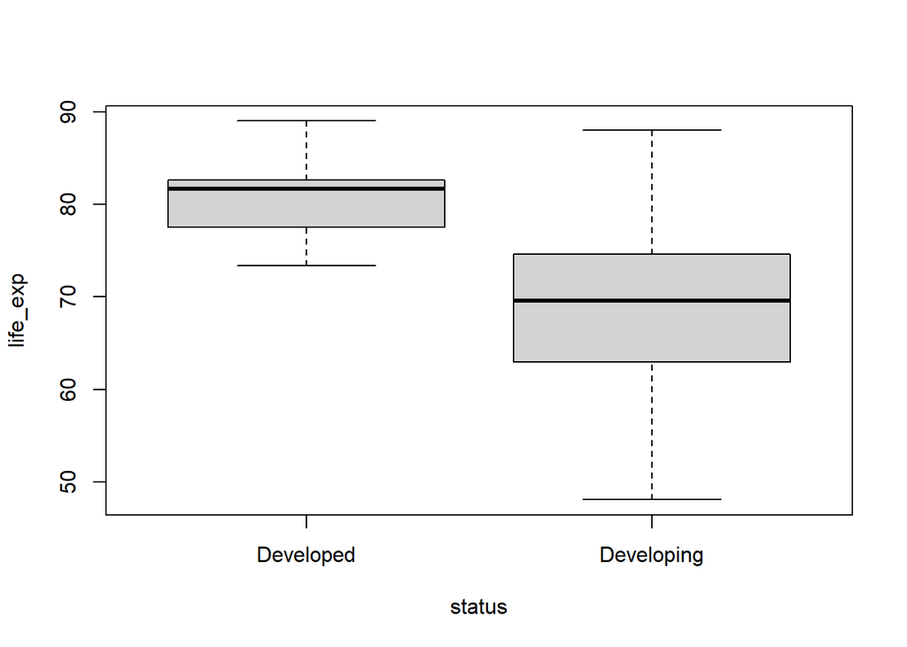

```r
attach(LE)
boxplot(life_exp~status)
```

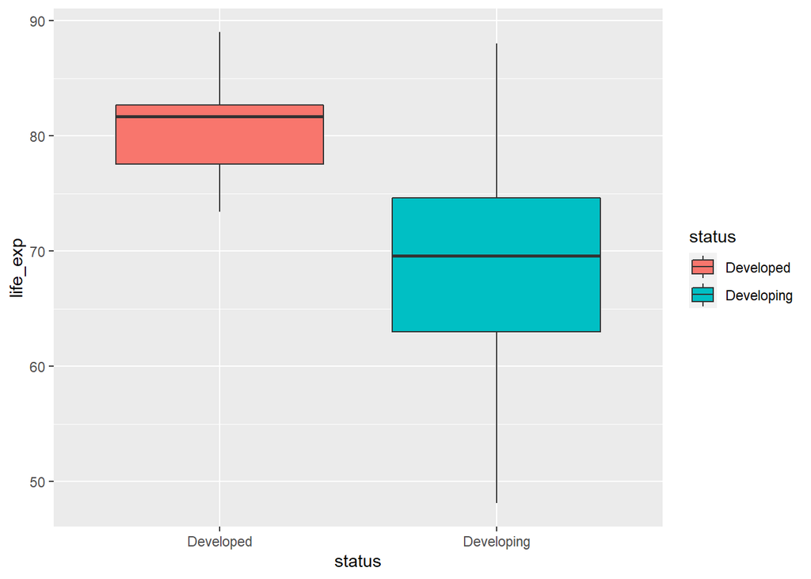

```r
ggplot(data = LE,
       aes(x=status, y=life_exp, fill=status))+
        geom_boxplot()
```

# Simple linear Regression

### Life expectancy and School

```r
attach(LE)
s_model_1 <- lm(formula = life_exp~school, data = LE)
summary(s_model_1)
```

```
##
## Call:
## lm(formula = life_exp ~ school, data = LE)
##
## Residuals:
##      Min       1Q   Median       3Q      Max
## -15.6180  -3.2318   0.5415   3.3678   9.3898
##
## Coefficients:
##             Estimate Std. Error t value Pr(>|t|)
## (Intercept)  38.7198     2.1350   18.14   <2e-16 ***
## school        2.5086     0.1646   15.24   <2e-16 ***
## ---
## Signif. codes:  0 '***' 0.001 '**' 0.01 '*' 0.05 '.' 0.1 ' ' 1
##
## Residual standard error: 5.162 on 129 degrees of freedom
## Multiple R-squared:  0.6429, Adjusted R-squared:  0.6401
## F-statistic: 232.2 on 1 and 129 DF,  p-value: < 2.2e-16
```

#### Model equation

$$E[Life.exp]=38.7198273+ 2.5086129School$$

#### Anova

```r
anova(s_model_1)
```

```
## Analysis of Variance Table
##
## Response: life_exp
##            Df Sum Sq Mean Sq F value    Pr(>F)
## school      1 6188.7  6188.7  232.22 < 2.2e-16 ***
## Residuals 129 3437.8    26.6
## ---
## Signif. codes:  0 '***' 0.001 '**' 0.01 '*' 0.05 '.' 0.1 ' ' 1
```

#### Visualization

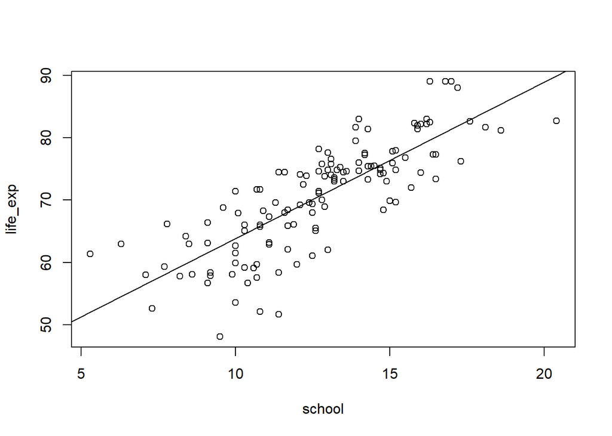

```r
plot(life_exp~school)
abline(s_model_1)
```

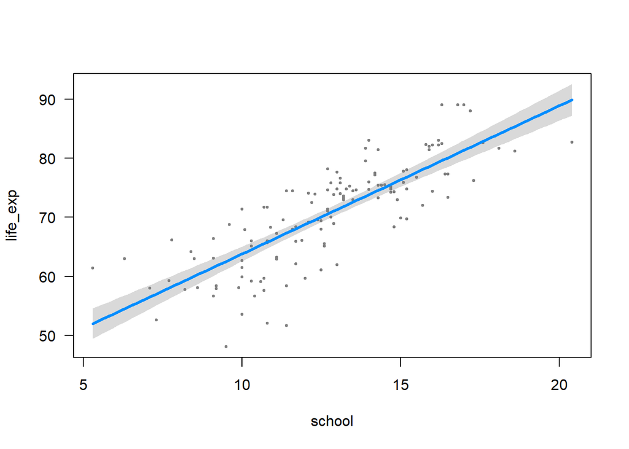

```r
library(visreg)
visreg(s_model_1)
```

#### Diagnoistic plots

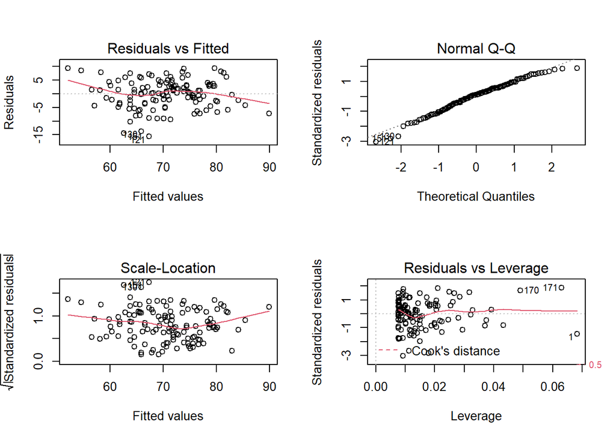

```r
par(mfrow=c(2,2))
plot(s_model_1)
```

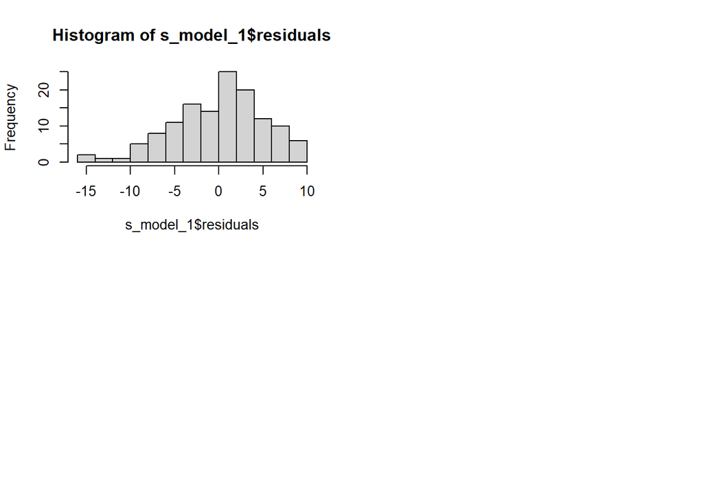

```r
hist(s_model_1$residuals)
```

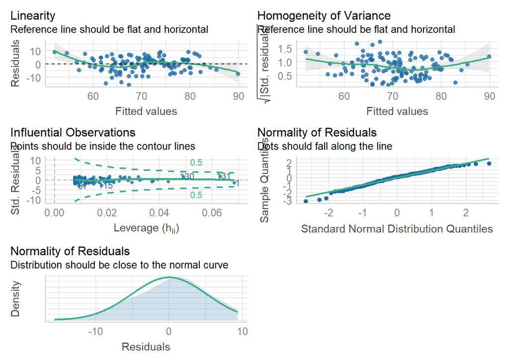

```r
library(performance)
library(see)
check_model(s_model_1)
```

### Life expectancy and Adult Mortality Rate

```r
s_model_2=lm(life_exp~adult_mort, data = LE)
summary(s_model_2)
```

```
##
## Call:
## lm(formula = life_exp ~ adult_mort, data = LE)
##
## Residuals:
##      Min       1Q   Median       3Q      Max
## -20.3434  -2.2459   0.5876   3.2654  13.5242
##
## Coefficients:
##              Estimate Std. Error t value Pr(>|t|)
## (Intercept) 80.168607   0.852736   94.01   <2e-16 ***
## adult_mort  -0.060164   0.004388  -13.71   <2e-16 ***
## ---
## Signif. codes:  0 '***' 0.001 '**' 0.01 '*' 0.05 '.' 0.1 ' ' 1
##
## Residual standard error: 5.511 on 129 degrees of freedom
## Multiple R-squared:  0.593,  Adjusted R-squared:  0.5899
## F-statistic:   188 on 1 and 129 DF,  p-value: < 2.2e-16
```

#### Model equation

$$E[Life.exp]=80.1686069+ -0.0601641Adult.mort$$

#### Anova

```r
anova(s_model_2)
```

```
## Analysis of Variance Table
##
## Response: life_exp
##             Df Sum Sq Mean Sq F value    Pr(>F)
## adult_mort   1 5708.6  5708.6  187.96 < 2.2e-16 ***
## Residuals  129 3917.9    30.4
## ---
## Signif. codes:  0 '***' 0.001 '**' 0.01 '*' 0.05 '.' 0.1 ' ' 1
```

#### Visualization

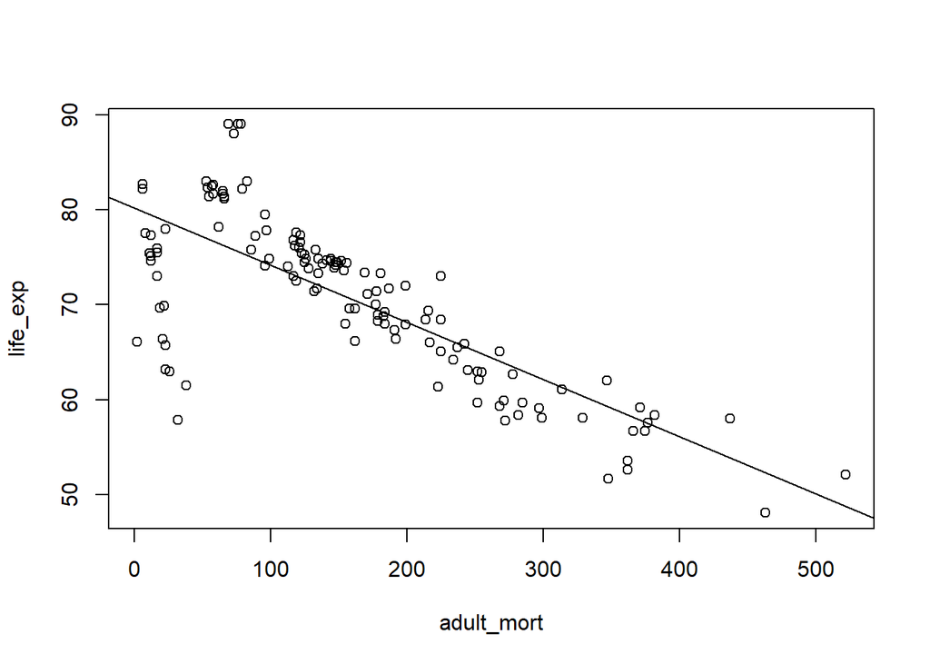

```r
plot(life_exp~adult_mort)
abline(s_model_2)
```

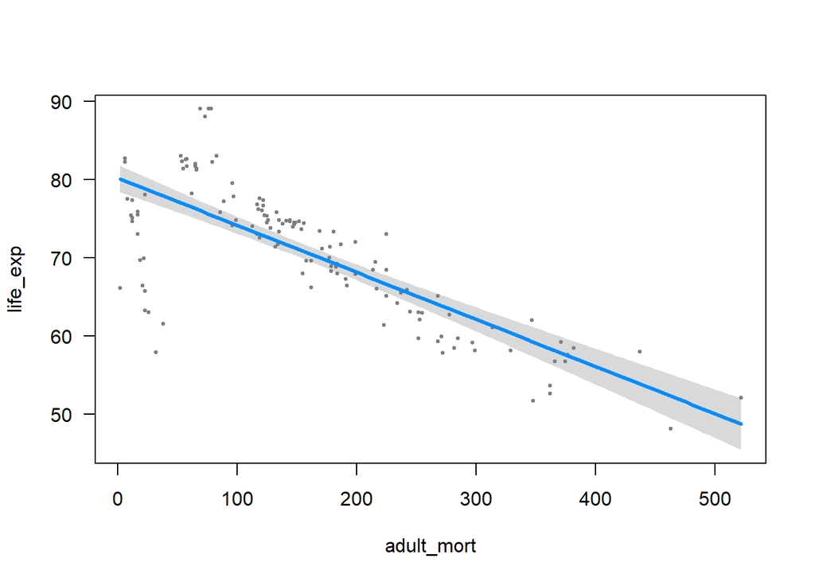

```r
visreg(s_model_2)
```

#### Diagnoistic plots

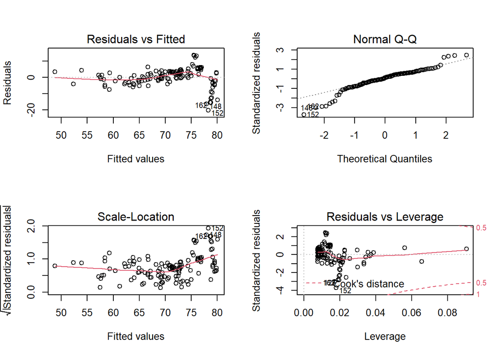

```r
par(mfrow=c(2,2))
plot(s_model_2)
```

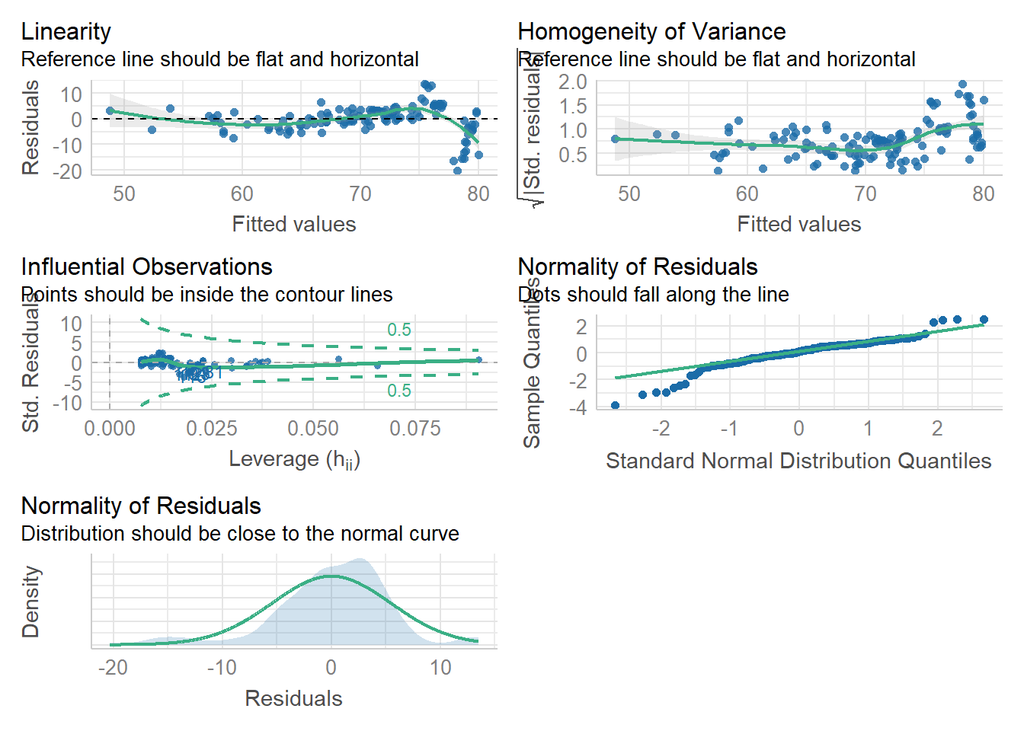

```r
check_model(s_model_2)
```

# Multipple Linear Regression

```r
LE_new=LE[,-1]
```

Let’s fit a multiple linear regression with all the other variables.

```r
m_model_1=lm(life_exp~., data = LE_new)
summary(m_model_1)
```

```
##
## Call:
## lm(formula = life_exp ~ ., data = LE_new)
##
## Residuals:
##      Min       1Q   Median       3Q      Max
## -10.4098  -1.7264  -0.0392   1.7715   8.3880
##
## Coefficients:
##                    Estimate Std. Error t value Pr(>|t|)
## (Intercept)       5.122e+01  3.314e+00  15.457  < 2e-16 ***
## statusDeveloping -1.170e+00  1.035e+00  -1.130 0.261006
## adult_mort       -1.724e-02  4.148e-03  -4.157 6.36e-05 ***
## inf_death         8.287e-02  5.619e-02   1.475 0.143057
## alcohol           5.674e-03  9.749e-02   0.058 0.953689
## perc_exp          4.627e-04  4.639e-04   0.997 0.320716
## hep_B             1.205e-02  2.808e-02   0.429 0.668582
## measles          -3.361e-05  4.823e-05  -0.697 0.487345
## BMI              -7.576e-03  2.000e-02  -0.379 0.705531
## under_5_d        -6.014e-02  3.838e-02  -1.567 0.119989
## polio            -8.746e-03  2.117e-02  -0.413 0.680327
## tot_exp           2.878e-01  1.274e-01   2.259 0.025833 *
## diphtheria        7.644e-03  3.445e-02   0.222 0.824805
## HIV              -8.363e-01  2.470e-01  -3.385 0.000984 ***
## GDP              -5.980e-05  6.656e-05  -0.898 0.370911
## pop              -1.729e-09  6.804e-09  -0.254 0.799816
## thin10_19        -1.300e-01  2.267e-01  -0.574 0.567462
## thin5_9           5.458e-03  2.227e-01   0.025 0.980489
## Income            3.597e+01  6.228e+00   5.775 7.11e-08 ***
## school           -1.617e-01  2.740e-01  -0.590 0.556279
## ---
## Signif. codes:  0 '***' 0.001 '**' 0.01 '*' 0.05 '.' 0.1 ' ' 1
##
## Residual standard error: 3.186 on 111 degrees of freedom
## Multiple R-squared:  0.8829, Adjusted R-squared:  0.8629
## F-statistic: 44.06 on 19 and 111 DF,  p-value: < 2.2e-16
```

## Variable Selection

### Forward Selection

```r
m_model_f=step(lm(life_exp~1, data = LE_new), direction = "forward", scope = life_exp~status + adult_mort + inf_death + alcohol + perc_exp +     hep_B + measles + BMI + under_5_d + polio + tot_exp + diphtheria +     HIV + GDP + pop + thin10_19 + thin5_9 + Income + school, trace = 0)
#trace=0 is just to prevent printing the output
```

```r
summary(m_model_f)
```

```
##
## Call:
## lm(formula = life_exp ~ Income + adult_mort + HIV + tot_exp,
##     data = LE_new)
##
## Residuals:
##      Min       1Q   Median       3Q      Max
## -10.3808  -1.6174  -0.0501   1.6143   9.9760
##
## Coefficients:
##              Estimate Std. Error t value Pr(>|t|)
## (Intercept) 47.614113   2.047692  23.253  < 2e-16 ***
## Income      36.285086   2.488491  14.581  < 2e-16 ***
## adult_mort  -0.017949   0.003855  -4.656 8.04e-06 ***
## HIV         -0.844894   0.230049  -3.673 0.000353 ***
## tot_exp      0.355162   0.111458   3.187 0.001816 **
## ---
## Signif. codes:  0 '***' 0.001 '**' 0.01 '*' 0.05 '.' 0.1 ' ' 1
##
## Residual standard error: 3.102 on 126 degrees of freedom
## Multiple R-squared:  0.8741, Adjusted R-squared:  0.8701
## F-statistic: 218.7 on 4 and 126 DF,  p-value: < 2.2e-16
```

### Backward Selection

```r
m_model_b=step(lm(life_exp~., data = LE_new), direction = "backward", trace = 0)
```

```r
summary(m_model_b)
```

```
##
## Call:
## lm(formula = life_exp ~ adult_mort + inf_death + under_5_d +
##     tot_exp + HIV + Income, data = LE_new)
##
## Residuals:
##     Min      1Q  Median      3Q     Max
## -10.568  -1.569  -0.127   1.561  10.060
##
## Coefficients:
##              Estimate Std. Error t value Pr(>|t|)
## (Intercept) 47.860575   2.066580  23.159  < 2e-16 ***
## adult_mort  -0.017405   0.003866  -4.502 1.53e-05 ***
## inf_death    0.042287   0.029527   1.432 0.154625
## under_5_d   -0.033561   0.022614  -1.484 0.140331
## tot_exp      0.349095   0.111930   3.119 0.002258 **
## HIV         -0.809261   0.231621  -3.494 0.000661 ***
## Income      35.911609   2.502726  14.349  < 2e-16 ***
## ---
## Signif. codes:  0 '***' 0.001 '**' 0.01 '*' 0.05 '.' 0.1 ' ' 1
##
## Residual standard error: 3.096 on 124 degrees of freedom
## Multiple R-squared:  0.8765, Adjusted R-squared:  0.8705
## F-statistic: 146.7 on 6 and 124 DF,  p-value: < 2.2e-16
```

### Stepwise Selection

```r
m_model_s=step(lm(life_exp~status + adult_mort + inf_death + alcohol + perc_exp +     hep_B + measles + BMI + under_5_d + polio + tot_exp + diphtheria +     HIV + GDP + pop + thin10_19 + thin5_9 + Income + school), direction = "both", trace = 0)
```

```r
summary(m_model_s)
```

```
##
## Call:
## lm(formula = life_exp ~ adult_mort + inf_death + under_5_d +
##     tot_exp + HIV + Income)
##
## Residuals:
##     Min      1Q  Median      3Q     Max
## -10.568  -1.569  -0.127   1.561  10.060
##
## Coefficients:
##              Estimate Std. Error t value Pr(>|t|)
## (Intercept) 47.860575   2.066580  23.159  < 2e-16 ***
## adult_mort  -0.017405   0.003866  -4.502 1.53e-05 ***
## inf_death    0.042287   0.029527   1.432 0.154625
## under_5_d   -0.033561   0.022614  -1.484 0.140331
## tot_exp      0.349095   0.111930   3.119 0.002258 **
## HIV         -0.809261   0.231621  -3.494 0.000661 ***
## Income      35.911609   2.502726  14.349  < 2e-16 ***
## ---
## Signif. codes:  0 '***' 0.001 '**' 0.01 '*' 0.05 '.' 0.1 ' ' 1
##
## Residual standard error: 3.096 on 124 degrees of freedom
## Multiple R-squared:  0.8765, Adjusted R-squared:  0.8705
## F-statistic: 146.7 on 6 and 124 DF,  p-value: < 2.2e-16
```

### Another models

```r
model_1=lm(life_exp ~ adult_mort + tot_exp + HIV + GDP , data = LE_new)
summary(model_1)
```

```
##
## Call:
## lm(formula = life_exp ~ adult_mort + tot_exp + HIV + GDP, data = LE_new)
##
## Residuals:
##     Min      1Q  Median      3Q     Max
## -12.764  -2.024   0.465   2.477  12.662
##
## Coefficients:
##               Estimate Std. Error t value Pr(>|t|)
## (Intercept)  7.348e+01  1.362e+00  53.958  < 2e-16 ***
## adult_mort  -4.267e-02  5.122e-03  -8.331 1.16e-13 ***
## tot_exp      6.319e-01  1.671e-01   3.783 0.000238 ***
## HIV         -1.139e+00  3.503e-01  -3.250 0.001480 **
## GDP          1.303e-04  2.966e-05   4.395 2.33e-05 ***
## ---
## Signif. codes:  0 '***' 0.001 '**' 0.01 '*' 0.05 '.' 0.1 ' ' 1
##
## Residual standard error: 4.735 on 126 degrees of freedom
## Multiple R-squared:  0.7066, Adjusted R-squared:  0.6973
## F-statistic: 75.85 on 4 and 126 DF,  p-value: < 2.2e-16
```

```r
AIC(model_1)
```

```
## [1] 786.053
```

```r
AIC(m_model_f)
```

```
## [1] 675.2337
```

Relationship between GDP and Income

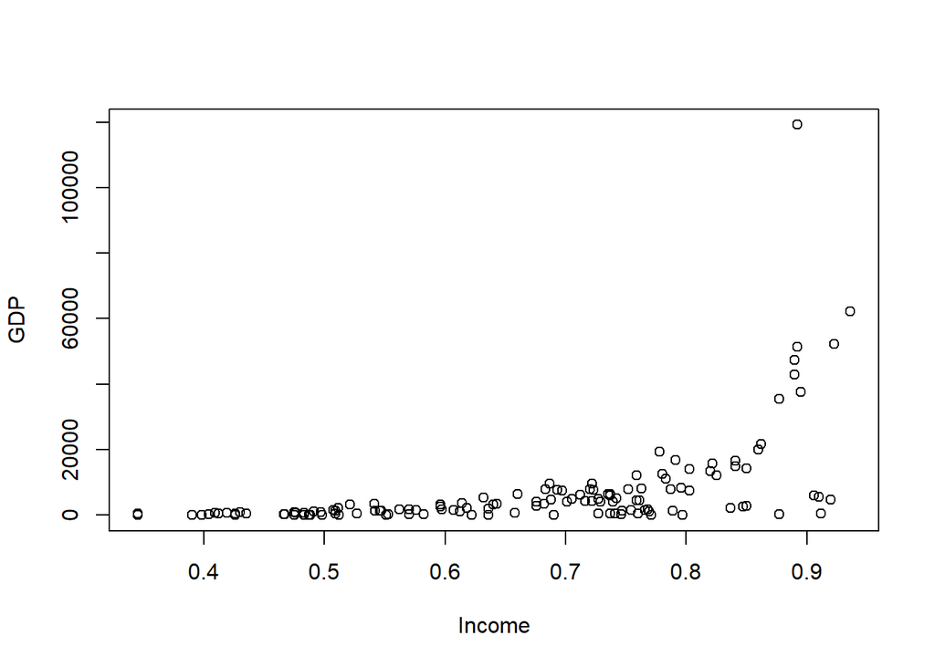

```r
plot(GDP~Income)
```

```r
anova(m_model_f, model_1)
```

```
## Analysis of Variance Table
##
## Model 1: life_exp ~ Income + adult_mort + HIV + tot_exp
## Model 2: life_exp ~ adult_mort + tot_exp + HIV + GDP
##   Res.Df    RSS Df Sum of Sq F Pr(>F)
## 1    126 1212.2
## 2    126 2824.6  0   -1612.4
```

```r
s_model_3=lm(life_exp~GDP)
summary(s_model_3)
```

```
##
## Call:
## lm(formula = life_exp ~ GDP)
##
## Residuals:
##      Min       1Q   Median       3Q      Max
## -20.5603  -5.6061   0.9268   5.0740  19.7700
##
## Coefficients:
##              Estimate Std. Error t value Pr(>|t|)
## (Intercept) 6.864e+01  7.544e-01  90.981  < 2e-16 ***
## GDP         2.590e-04  4.606e-05   5.624  1.1e-07 ***
## ---
## Signif. codes:  0 '***' 0.001 '**' 0.01 '*' 0.05 '.' 0.1 ' ' 1
##
## Residual standard error: 7.741 on 129 degrees of freedom
## Multiple R-squared:  0.1969, Adjusted R-squared:  0.1907
## F-statistic: 31.63 on 1 and 129 DF,  p-value: 1.103e-07
```

Best model sofar

```r
best_model=m_model_f
summary(best_model)
```

```
##
## Call:
## lm(formula = life_exp ~ Income + adult_mort + HIV + tot_exp,
##     data = LE_new)
##
## Residuals:
##      Min       1Q   Median       3Q      Max
## -10.3808  -1.6174  -0.0501   1.6143   9.9760
##
## Coefficients:
##              Estimate Std. Error t value Pr(>|t|)
## (Intercept) 47.614113   2.047692  23.253  < 2e-16 ***
## Income      36.285086   2.488491  14.581  < 2e-16 ***
## adult_mort  -0.017949   0.003855  -4.656 8.04e-06 ***
## HIV         -0.844894   0.230049  -3.673 0.000353 ***
## tot_exp      0.355162   0.111458   3.187 0.001816 **
## ---
## Signif. codes:  0 '***' 0.001 '**' 0.01 '*' 0.05 '.' 0.1 ' ' 1
##
## Residual standard error: 3.102 on 126 degrees of freedom
## Multiple R-squared:  0.8741, Adjusted R-squared:  0.8701
## F-statistic: 218.7 on 4 and 126 DF,  p-value: < 2.2e-16
```

#### Model equation

$$E[Life.exp]=47.6141131+ 36.2850855Income + -0.0179486adult.mort + -0.8448937HIV + 0.355162tot.exp$$

#### Model Diagnostics

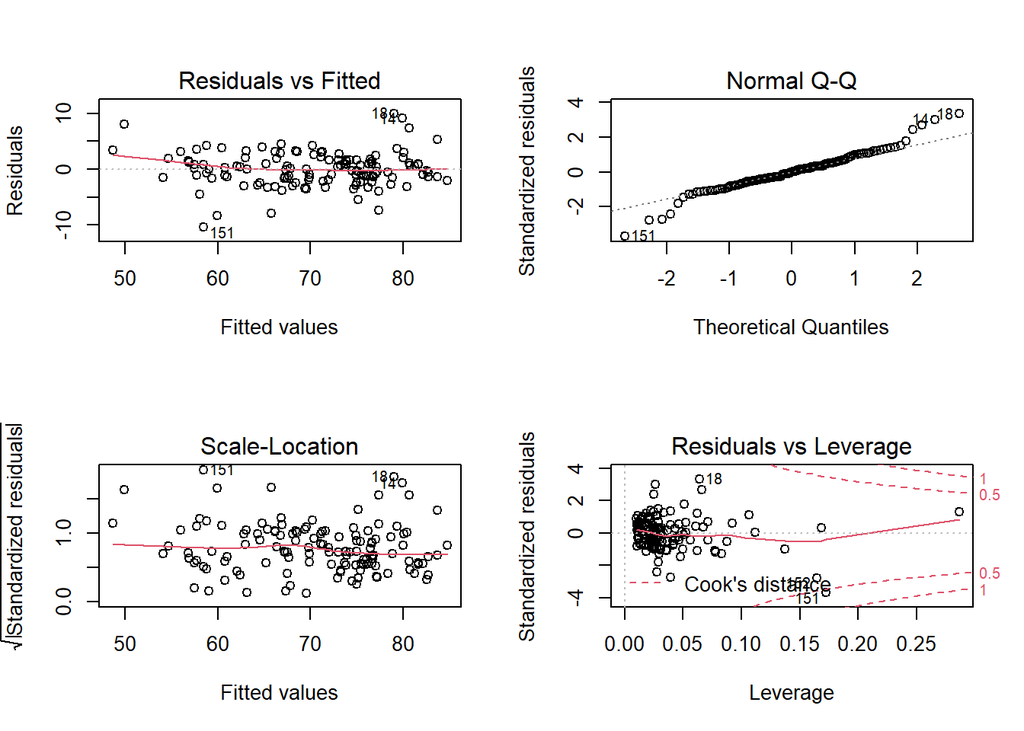

```r
par(mfrow=c(2,2))
plot(best_model)
```

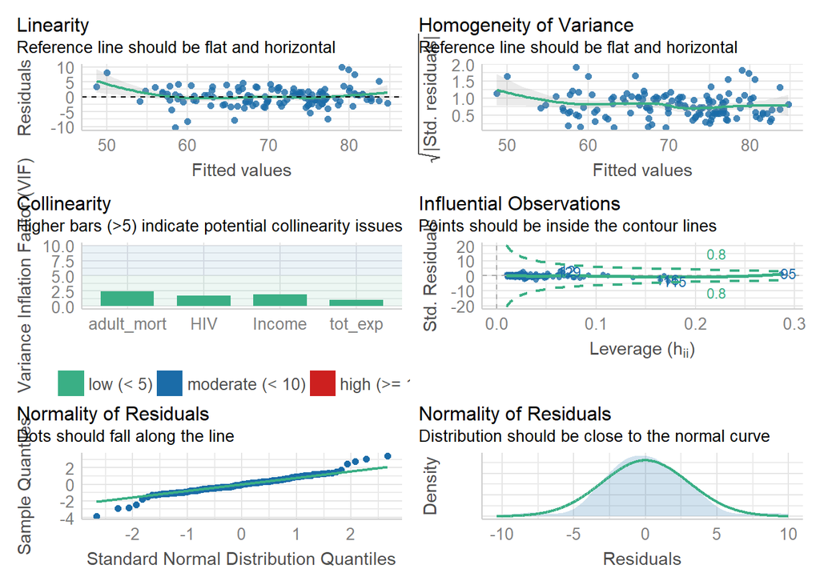

```r
check_model(best_model)
```

### Model with Interaction

```r
m2=lm(life_exp~adult_mort+HIV+tot_exp+I(tot_exp*adult_mort))
summary(m2)
```

```
##
## Call:
## lm(formula = life_exp ~ adult_mort + HIV + tot_exp + I(tot_exp *
##     adult_mort))
##
## Residuals:
##      Min       1Q   Median       3Q      Max
## -14.4421  -2.1158   0.1147   2.7738  18.6184
##
## Coefficients:
##                          Estimate Std. Error t value Pr(>|t|)
## (Intercept)             70.498867   1.892509  37.252  < 2e-16 ***
## adult_mort              -0.022206   0.009550  -2.325  0.02166 *
## HIV                     -1.224578   0.364146  -3.363  0.00102 **
## tot_exp                  1.372080   0.264974   5.178 8.61e-07 ***
## I(tot_exp * adult_mort) -0.004045   0.001275  -3.173  0.00190 **
## ---
## Signif. codes:  0 '***' 0.001 '**' 0.01 '*' 0.05 '.' 0.1 ' ' 1
##
## Residual standard error: 4.893 on 126 degrees of freedom
## Multiple R-squared:  0.6866, Adjusted R-squared:  0.6767
## F-statistic: 69.02 on 4 and 126 DF,  p-value: < 2.2e-16
```

```r
AIC(m2)
```

```
## [1] 794.668
```

```r
AIC(m_model_f)
```

```
## [1] 675.2337
```